# 🌊 Sea Level Predictor

Predicting future sea level, this time in Python, as part of the FreeCodeCamp assignment.

```python
import pandas as pd
import matplotlib.pyplot as plt
from scipy import stats # used for the trend line (line of best fit)
```

```python
df = pd.read_csv('epa-sea-level.csv')
```

```python
df.head()
```

|  | Year | CSIRO Adjusted Sea Level | Lower Error Bound | Upper Error Bound | NOAA Adjusted Sea Level |
| --- | --- | --- | --- | --- | --- |
| 0 | 1880 | 0.000000 | -0.952756 | 0.952756 | NaN |
| 1 | 1881 | 0.220472 | -0.732283 | 1.173228 | NaN |
| 2 | 1882 | -0.440945 | -1.346457 | 0.464567 | NaN |
| 3 | 1883 | -0.232283 | -1.129921 | 0.665354 | NaN |
| 4 | 1884 | 0.590551 | -0.283465 | 1.464567 | NaN |

This file contains historical records of global average sea level since 1880.

- Year: self-explanatory
- CSIRO Adjusted Sea Level: the sea level in inches, adjusted for missing data and land movement

The purpose is to understand how sea level has changed over time and use that to make predictions.

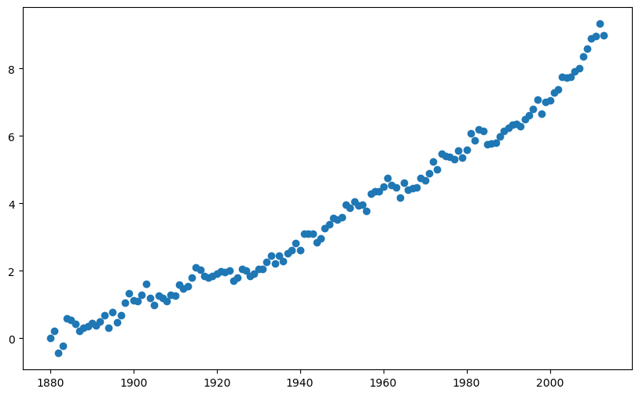

```python
plt.figure(figsize=(10, 6))
plt.scatter(df['Year'], df['CSIRO Adjusted Sea Level'])
```

This is good for showing the relationship between two vars. Year & Sea lvl. We can capture the trend.

We can use linear regression to find a straight line that best fits the data.

```python
slope, intercept, r_value, p_value, std_err = stats.linregress(df['Year'], df['CSIRO Adjusted Sea Level'])
```

We use linegress as it gives the slope and intercept of the best-fit line, which I can use to make predictions. Even though climate change might not be perfectly linear, a linear model is a good starting point for long-term trends.

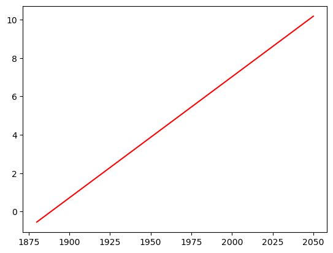

```python
years_extended = list(range(1880, 2051))  # From 1880 to 2050 inclusive

line_all_data = [slope * year + intercept for year in years_extended]
plt.plot(years_extended, line_all_data, 'r', label='Fitted line (1880-present)')
```

I noticed that sea level rise might be accelerating in recent decades. So, I want to test a second hypothesis:

What if we only use data from 2000 onward?

```python
df_recent = df[df['Year'] >= 2000]
```

```python
slope_recent, intercept_recent, _, _, _ = stats.linregress(df_recent['Year'], df_recent['CSIRO Adjusted Sea Level'])
```

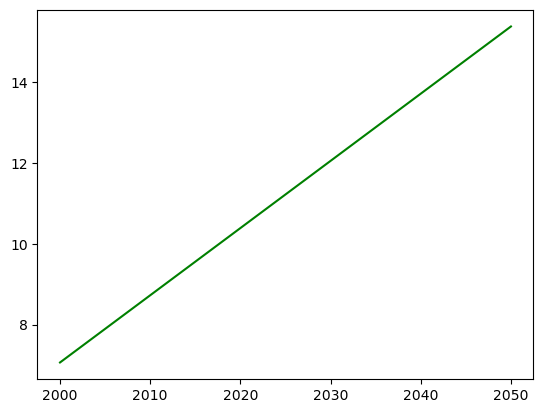

```python
years_future = list(range(2000, 2051))
line_recent = [slope_recent * year + intercept_recent for year in years_future]
plt.plot(years_future, line_recent, 'g', label='Fitted line (2000-present)')
```

Now, putting together the entire draw_plot() function

```python
import pandas as pd
import matplotlib.pyplot as plt
from scipy import stats

def draw_plot():
    # Load data
    df = pd.read_csv('epa-sea-level.csv')

    # Create scatter plot
    plt.figure(figsize=(10, 6))
    plt.scatter(df['Year'], df['CSIRO Adjusted Sea Level'], s=5)

    # First line of best fit (1880 to 2050)
    slope, intercept, r_value, p_value, std_err = stats.linregress(df['Year'], df['CSIRO Adjusted Sea Level'])
    years_extended = list(range(1880, 2051))
    line_all_data = [slope * year + intercept for year in years_extended]
    plt.plot(years_extended, line_all_data, 'r', label='Fitted line (1880-present)')

    # Second line of best fit (2000 to 2050)
    df_recent = df[df['Year'] >= 2000]
    slope_recent, intercept_recent, _, _, _ = stats.linregress(df_recent['Year'], df_recent['CSIRO Adjusted Sea Level'])
    years_future = list(range(2000, 2051))
    line_recent = [slope_recent * year + intercept_recent for year in years_future]
    plt.plot(years_future, line_recent, 'g', label='Fitted line (2000-present)')

    # Labels and title
    plt.xlabel('Year')
    plt.ylabel('Sea Level (inches)')
    plt.title('Rise in Sea Level')
    plt.legend()

    # Save and return
    plt.tight_layout()
    fig = plt.gcf()
    fig.savefig('sea_level_plot.png')
    return fig
```

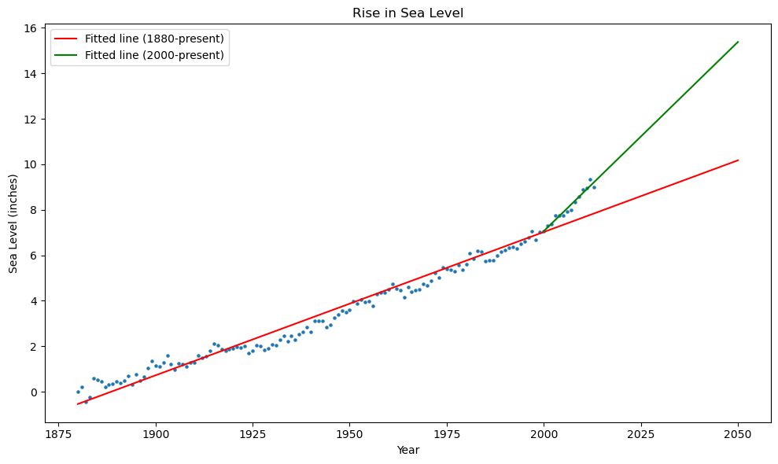

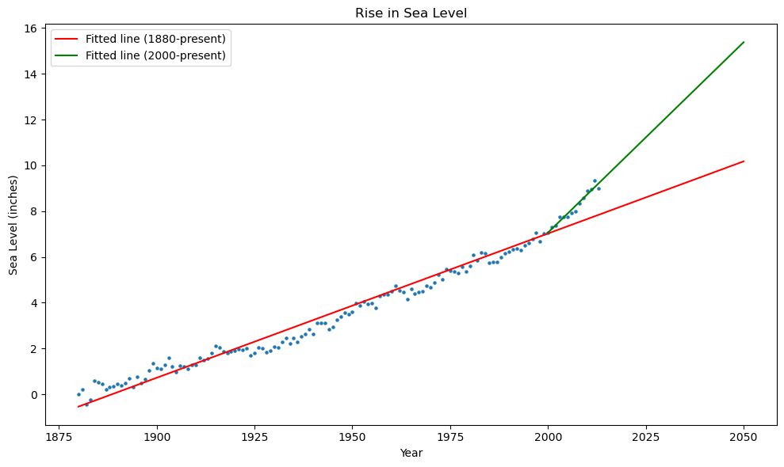

```python
draw_plot()
```

- Sea levels have been rising — the scatter plot makes that clear.
- The first line (1880–2013) gives a conservative estimate of future rise.
- The second line (2000–2013) appears steeper — suggesting an acceleration in sea level rise.
- By 2050, the two models may predict very different outcomes — showing how sensitive predictions are to the time period we choose.